# importance sampling

### 예제 1.

$Z \sim N(0,1)$

우리는 $Pr(Z>4.5)$확률을 알고 싶다고 하자.

[!!] 이런것을 해본적 있다. (노트3에 예제3번)

### 3주차 예제3: $\int_{-\infty}^{t}\frac{1}{\sqrt{2\pi}}e^{-x^2/2}dx=?$

```r
t<-1.96
n<-10000
X<-rnorm(n)
sum(X<t)/n
```

0.9746

똑같이 풀면된다. 즉 $\int_{4.5}^{\infty}\frac{1}{\sqrt{2\pi}}e^{-x^2/2}dx$를 계산하면 된다.

```r
t<-4.5
n<-10000
X<-rnorm(n)
sum(X>t)/n
```

0

??

**[문제점]** 4.5 이상을 얻을려면 굉장이 많은 샘플을 뽑아야함.

```r
max(rnorm(300))
```

2.74213118367203

```r
max(rnorm(3000))
```

4.07845909009187

```r
max(rnorm(30000))
```

4.33064781572162

```r
max(rnorm(300000))
```

4.67159105313342

```r
sum(rnorm(300000)>4.5)
```

0

```r
sum(rnorm(300000)>4.5) / 300000
```

1e-05

관심이 있는 이벤트가 잘 일어나지 않는 케이스라면 나이브한 접근법으로는 한계가 있음.

매우 많은 시뮬레이션을 해야 한다는 문제점이 있음.

**[문제상황 명확히 파악]**

```r
x<- -7000:7000/1000
```

```r
target<- function(x){
    1/sqrt(2*pi) * exp(-x^2/2)
}
```

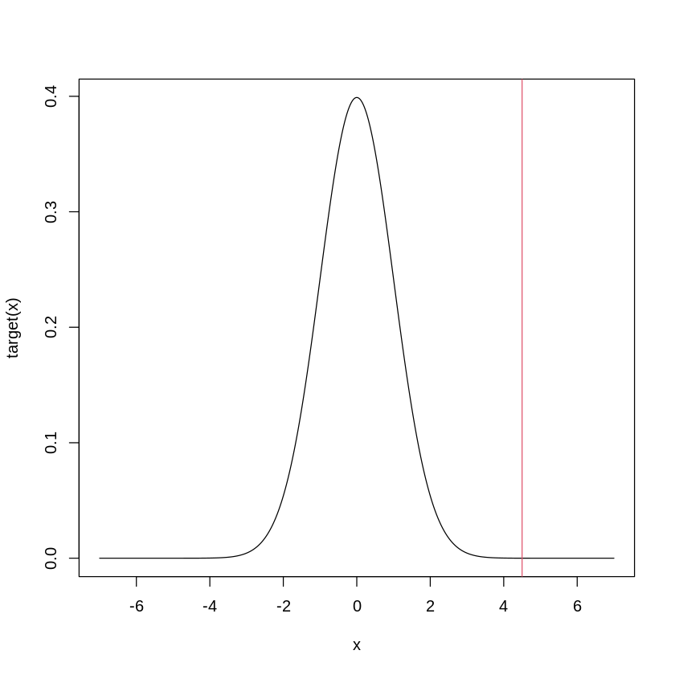

```r
plot(x,target(x),type='l')
abline(v=4.5,col=2)
```

잘 안보이므로 확대를 하자.

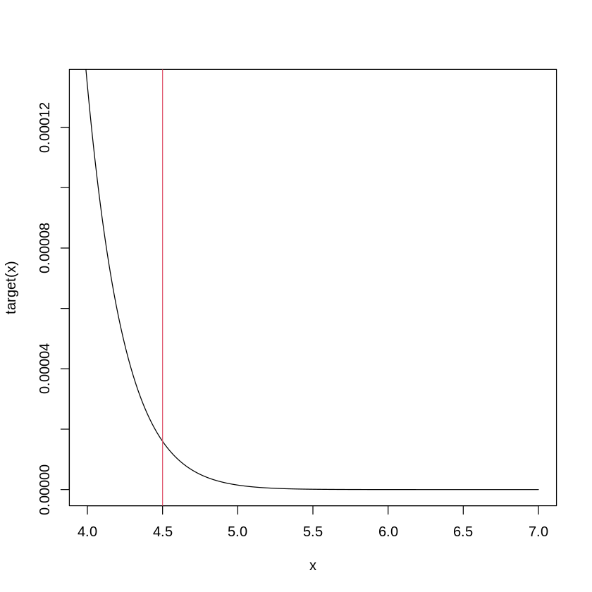

```r
plot(x,target(x),type='l',xlim=c(4,7),ylim=c(0,f(4)))
abline(v=4.5,col=2)
```

결국 빨간선의 오른쪽 영역을 적분하면 된다는 이야기.

이런것을 어디서 본 것 같다.

무한 적분구간을 가지는 피적분함수를 적분하는 방법 (3주차!)

### 3주차 예제1: $\int_0^{\infty}\frac{1}{(x+1)^2}dx=?$

(해석적풀이)

$\int_0^{\infty}\frac{1}{(x+1)^2}dx=\int_1^{\infty}\frac{1}{u^2}du$

$=\left[-u^{-1} \right]_1^{\infty}=1$

(몬테카를로)

그런데, 우리가 관심있는 것은 $\int_0^{\infty} target(x)dx$이다.

$refer(x)$는 지수분포이므로 $\int_0^{\infty}refer(x)dx=1$인데, 공교롭게도 적분구간이 겹친다.

관심수식을 다시 표현하면

$\int_0^{\infty}targer(x)dx=\int_0^{\infty}\frac{target(x)}{refer(x)}refer(x)dx$

$=E\left[\frac{target(X)}{refer(X)} \right]$

와 같이 표현할 수 있다.

```r
n=10000
lambda=0.05
X<-rexp(n,lambda)
refer<-lambda*exp(-X*lambda)
target<-1/((1+X)^2)
mean(target/refer)
```

1.0013041881067

위의 예제를 조금만 응용하면 될 것 같다.

#### Step 1. target 함수의 조정

타겟함수는 아래와 같다.

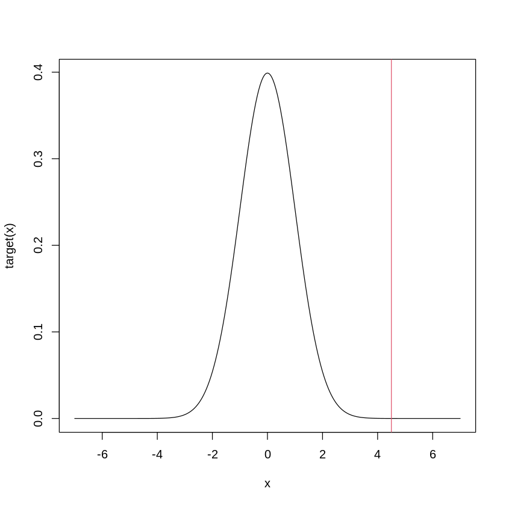

```r
target<- function(x){
    1/sqrt(2*pi) * exp(-x^2/2)
}
plot(x,target(x),type='l')
abline(v=4.5,col=2)
```

그런데 타겟함수를 아래와 같이 생각해도 무방하다.

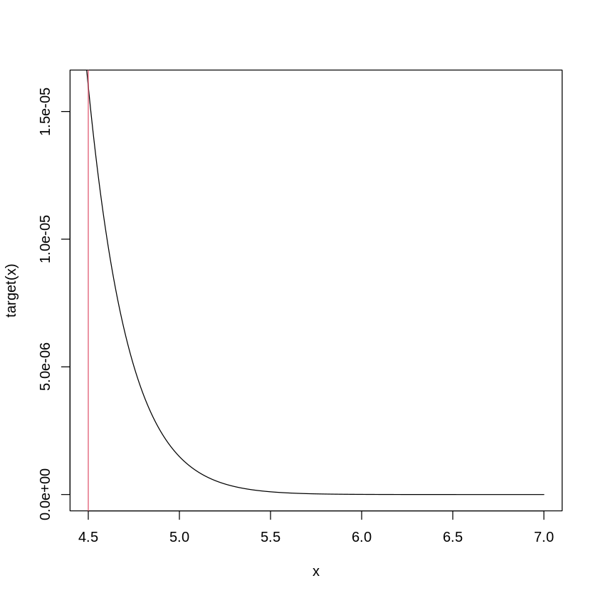

```r
plot(x,target(x),type='l',xlim=c(4.5,7),ylim=c(0,f(4.5)))
abline(v=4.5,col=2)
```

타겟함수를 $x>4.5$에서만 (제대로) 정의하고 나머지 값은 신경안써도 된다.

우리가 원래 하고싶었던것: $\int_{4.5}^{\infty}target(x)dx$

$\int_{4.5}^{\infty}target(x)dx$

$=\int_{-\infty}^{\infty}target(x)I(x>4.5)dx$

$=\int_{-\infty}^{\infty}\mbox{modified-}target(x)dx$

원래 타겟함수: $\frac{1}{\sqrt{2\pi}}e^{-x^2/2}$

새로운 타겟함수: $\frac{1}{\sqrt{2\pi}}e^{-x^2/2}I(x>4.5)$

#### Step 2. reference 함수의 조정

[사실] 원래 참조함수를 선택하는 조건은 (1) 확률밀도함수 이어야 하고 (2) 참조함수의 support가 타겟함수의 support를 커버하면 된다.

support의 의미는

$\mbox{supp}(target)=\big\{x:target(x)\neq 0 \big\}$

이다.

참조함수의 support가 target 함수의 support를 커버한다는 말의 의미는

$\mbox{supp}(taget) \subset \mbox{supp}(refer)$

이다.

$target(x)$가 양수인곳은 반드시 $refer(x)$도 양수이어야 한다는 의미이다.

$target(x)=0$ 인지점에서 $refer(x)>0$ 인것은 (이론상으로) 전혀 문제가 없다.

[직관] 실질적으로는 참조함수의 support가 타겟함수의 support를 잘 덮어야 효율이 좋다.

[난관] 무한적분 구간을 가지는 타겟함수를 덮기위해서 많이 선호하는 참조분포는 "지수분포"이다.

그런데, 지수분포는 대부분의 값이 1에 몰려있고, 그래서 4.5이상 나오는 값들이 그다지 많지 않아 효율이 좋지 않다.

[욕심] $x>4.5$에서만 랜덤변수가 발생되는 어떠한 pdf를 알 수 있을까? $\to$ [해결] 조건부분포를 활용

*참고분포: 지수분포에서 조건부 pdf를 유도하여 사용하자.*

$\mbox{modified-}refer(y)=\frac{e^{-y}}{\int_{4.5}^{\infty}e^{-y}dy}$

당연히 $\mbox{modified-}refer(y)$ 역시 확률밀도함수이고, 타겟함수의 supp를 잘 덮으므로 (cover) 이론적으로 적절한 참조함수이다.

또한 위와 같은 참조함수를 사용하면 4.5이상의 값들만 생성된다. 따라서 적분값을 효율적으로 추정할 수 있으므로 실용적이다.

갑자기 확률변수를 생성할 생각에 머리가 아프다. (rejection sampling, inverse cdf..?)

하지만 어려운 방법으로 하지 않아도 쉽게 샘플링 할 수 있다.

$\mbox{modified}-refer(y)$의 분모만 계산해보자.

$\int_{4.5}^{\infty}e^{-y}dy=\big[-e^{-y}\big]_{4.5}^{\infty}=e^{-4.5}$

결국 $\mbox{modified-}refer(y)=e^{-(y-4.5)}$ 가 된다.

이것은 지수분포에서 4.5를 더한것의 pdf가 된다.

따라서 $modified\mbox{-}refer(y)$에서 확률변수를 얻기위해서는

(i) 평균이 1인 지수분포를 얻고,

(ii) (i)의 결과에서 4.5를 더하면

된다.

#### # 사실은 Step1은 필요없다. (참조함수만 조정하면 된다.)

앞으로의 전략은 수정된 참조분포에서 확률변수 $Y_1,\dots,Y_n$을 생성하고

$\frac{target^*(Y_1)}{refer^*(Y_1)},\frac{target^*(Y_2)}{refer^*(Y_2)},\dots \frac{target^*(Y_n)}{refer^*(Y_n)}$,

의 sample mean을 구하는 것이다. (단 $target^*$, $refer^*$는 각각 수정된(modified) 버전)

그런데 $Y_1,Y_2,\dots,Y_n$의 값은 항상 4.5보다 크므로

$target(Y_1)=target^*(Y_1)$

$target(Y_2)=target^*(Y_2)$

$...$

$target(Y_n)=target^*(Y_n)$

이다.

### Step 3. 이제 $\frac{target(y)}{modified^*(y)}$를 계산해보자.

$\frac{target(y)}{modified^*(y)}=\frac{A}{B}$

$A=\frac{1}{\sqrt{2\pi}}e^{-y^2/2}$

$B=e^{-(y-4.5)}$

따라서 $A/B=\frac{1}{\sqrt{2\pi}}e^{-y^2/2+y-4.5}$

편의상 $A/B$를 `k`로 정의하자.

(풀이)

```r
n<-300000
Y<-rexp(n)+4.5
k<-function(y){
    exp(-y^2/2+y-4.5)/sqrt(2*pi)
}
mean(k(Y))
```

3.39330949626975e-06

참값은

```r
pnorm(-4.5)
```

3.39767312473006e-06

### 일반화

원래문제: $\int_{4.5}^{\infty}\frac{1}{\sqrt{2\pi}}e^{-y^2/2}dy=?$

(1) (조정된) 참조분포: $g$

- $g$는 지수분포에서 4.5를 더한 확률변수의 pdf
- $g(y)=\frac{e^{-y}}{\int_{4.5}^{\infty}e^{-y}dy}=e^{-(y-4.5)}$

(2) 타겟함수: $f$

- $f$는 정규분포의 pdf
- $f(x)=\frac{1}{\sqrt{2\pi}}e^{-x^2/2}$

(3) 타겟을 조정하는 함수 $h$

- $h(x)=I(x>4.5)$

우리가 원래 원했던것: $\int_{4.5}^{\infty}f(x)dx=\int_{-\infty}^{\infty}f(x)h(x)dx=E_f(h(X))$

대신구할것: $\frac{1}{n}\sum_{i=1}^n\frac{f(Y_i)h(Y_i)}{g(Y_i)}$

$X$를 확률변수라고 하고 $f(x)$는 $X$의 pdf라고 하자.

$f(x)$와 전혀 상관없는 또다른 pdf $g(x)$를 생각하자.

구분을 하기 위해서 $g$를 따르는 확률변수 $Y$라고 하자.

즉

- $X \sim F(\cdot)$
- $Y \sim G(\cdot)$

$E_f\big[h(X)\big]=\int h(x)f(x)dx= \int h(x) \frac{f(x)}{g(x)}g(x)dx$

$=\int h(y)\frac{f(y)}{g(y)}g(y)dy=E_g\big[\frac{h(Y)f(Y)}{g(Y)}\big]$

위의 식이 의미하는 바는 아래와 같다.

(a) $X_1,\dots X_n$ 을 $f(x)$로부터 추출한뒤, 함수 $h$를 취해서 $h(X_1),\dots,h(X_n)$을 만들고 표본평균을 구한다.

(b) $Y_1,\dots,Y_n$ 을 $g(y)$에서 추출한 뒤, 함수 $h$, $f$를 취하여 $\frac{h(Y_1)f(Y_1)}{g(Y_1)},\frac{h(Y_2)f(Y_2)}{g(Y_2)},\dots,\frac{h(Y_n)f(Y_n)}{g(Y_n)} $를 만들고 표본평균을 구한다.

(a)와 (b)가 근사적으로 동일하다.